# ST558 Project 1

Xi Zeng

2022-09-07

## Data Processing

```r
library(readr)
sheet1 <- read_csv("https://www4.stat.ncsu.edu/~online/datasets/EDU01a.csv")
```

### First steps

```r
library(tidyverse)
#Step 1.select columns
newsheet <- sheet1 %>%
              rename("area_name" = Area_name)%>%
              select(area_name,STCOU,ends_with("D"))%>%
#Step 2.Convert data into long format
              pivot_longer(cols=ends_with("D"),names_to = "original_columns",values_to = "value")%>%
#Step 3.Create new variables
               mutate(Year = ifelse(as.numeric(substr(original_columns,start =8, stop = 9)) <= 22,
                                      as.numeric(paste0("20",substr(original_columns,start =8, stop = 9))),
                                        as.numeric(paste0("19",substr(original_columns,start =8, stop = 9)))),
                       Measurement = substr(original_columns,start =1, stop = 7))
```

Step 4.Create county dataset and non-county dataset.

```r
(county_tibble <- newsheet[grep(pattern = ", \\w\\w", newsheet$area_name),])
```

```
## # A tibble: 31,450 × 6
##    area_name   STCOU original_columns value  Year Measurement
##    <chr>       <chr> <chr>            <dbl> <dbl> <chr>
##  1 Autauga, AL 01001 EDU010187D        6829  1987 EDU0101
##  2 Autauga, AL 01001 EDU010188D        6900  1988 EDU0101
##  3 Autauga, AL 01001 EDU010189D        6920  1989 EDU0101
##  4 Autauga, AL 01001 EDU010190D        6847  1990 EDU0101
##  5 Autauga, AL 01001 EDU010191D        7008  1991 EDU0101
##  6 Autauga, AL 01001 EDU010192D        7137  1992 EDU0101
##  7 Autauga, AL 01001 EDU010193D        7152  1993 EDU0101
##  8 Autauga, AL 01001 EDU010194D        7381  1994 EDU0101
##  9 Autauga, AL 01001 EDU010195D        7568  1995 EDU0101
## 10 Autauga, AL 01001 EDU010196D        7834  1996 EDU0101
## # … with 31,440 more rows
```

```r
(not_county_tibble <-newsheet[-grep(pattern = ", \\w\\w", newsheet$area_name),])
```

```
## # A tibble: 530 × 6
##    area_name     STCOU original_columns    value  Year Measurement
##    <chr>         <chr> <chr>               <dbl> <dbl> <chr>
##  1 UNITED STATES 00000 EDU010187D       40024299  1987 EDU0101
##  2 UNITED STATES 00000 EDU010188D       39967624  1988 EDU0101
##  3 UNITED STATES 00000 EDU010189D       40317775  1989 EDU0101
##  4 UNITED STATES 00000 EDU010190D       40737600  1990 EDU0101
##  5 UNITED STATES 00000 EDU010191D       41385442  1991 EDU0101
##  6 UNITED STATES 00000 EDU010192D       42088151  1992 EDU0101
##  7 UNITED STATES 00000 EDU010193D       42724710  1993 EDU0101
##  8 UNITED STATES 00000 EDU010194D       43369917  1994 EDU0101
##  9 UNITED STATES 00000 EDU010195D       43993459  1995 EDU0101
## 10 UNITED STATES 00000 EDU010196D       44715737  1996 EDU0101
## # … with 520 more rows
```

```r
#Add class to both datasets
(class(county_tibble) <- c("county", class(county_tibble)))
```

```
## [1] "county"     "tbl_df"     "tbl"        "data.frame"
```

```r
(class(not_county_tibble) <- c("state", class(not_county_tibble)))
```

```
## [1] "state"      "tbl_df"     "tbl"        "data.frame"
```

Step 5.Create a new variable in county level tibble.

```r
(county_tibble <- mutate(county_tibble,state = substr(area_name, nchar(area_name)-1, nchar(area_name))))
```

```
## # A tibble: 31,450 × 7
##    area_name   STCOU original_columns value  Year Measurement state
##    <chr>       <chr> <chr>            <dbl> <dbl> <chr>       <chr>
##  1 Autauga, AL 01001 EDU010187D        6829  1987 EDU0101     AL
##  2 Autauga, AL 01001 EDU010188D        6900  1988 EDU0101     AL
##  3 Autauga, AL 01001 EDU010189D        6920  1989 EDU0101     AL
##  4 Autauga, AL 01001 EDU010190D        6847  1990 EDU0101     AL
##  5 Autauga, AL 01001 EDU010191D        7008  1991 EDU0101     AL
##  6 Autauga, AL 01001 EDU010192D        7137  1992 EDU0101     AL
##  7 Autauga, AL 01001 EDU010193D        7152  1993 EDU0101     AL
##  8 Autauga, AL 01001 EDU010194D        7381  1994 EDU0101     AL
##  9 Autauga, AL 01001 EDU010195D        7568  1995 EDU0101     AL
## 10 Autauga, AL 01001 EDU010196D        7834  1996 EDU0101     AL
## # … with 31,440 more rows
```

Step 6.Create a new variable in non-county dataset.

```r
#Set division for each state
Division1 <- c("CONNECTICUT","MAINE","MASSACHUSETTS","NEW HAMPSHIRE","RHODE ISLAND","VERMONT")
Division2 <- c("NEW JERSEY","NEW YORK","PENNSYLVANIA")
Division3 <- c("ILLINOIS","INDIANA","MICHIGAN","OHIO","WISCONSIN")
Division4 <- c("IOWA","KANSAS","MINNESOTA","MISSOURI","NEBRASKA","NORTH DAKOTA","SOUTH DAKOTA")
Division5 <- c("DELAWARE","FLORIDA","GEORGIA","MARYLAND","NORTH CAROLINA","SOUTH CAROLINA","VIRGINIA","WASHINGTON","D.C.","WEST VIRGINIA")
Division6 <- c("ALABAMA","KENTUCKY","MISSISSIPPI","TENNESSEE")
Division7 <- c("ARKANSAS","LOUISIANA","OKLAHOMA","TEXAS")
Division8 <- c("ARIZONA","COLORADO","IDAHO","MONTANA","NEVADA","NEW MEXICO","UTAH","WYOMING")
Division9 <- c("ALASKA","CALIFORNIA","HAWAII","OREGON","WASHINGTON")

#Create new column using ifelse logic
not_county_tibble <- mutate(not_county_tibble,
                            division = ifelse(area_name %in% Division1,1,
                                         ifelse(area_name %in% Division2,2,
                                           ifelse(area_name %in% Division3,3,
                                              ifelse(area_name %in% Division4,4,
                                                ifelse(area_name %in% Division5,5,
                                                  ifelse(area_name %in% Division6,6,
                                                    ifelse(area_name %in% Division7,7,
                                                      ifelse(area_name %in% Division8,8,
                                                        ifelse(area_name %in% Division9,9,"ERROR"))))))))))
not_county_tibble
```

```
## # A tibble: 530 × 7
##    area_name     STCOU original_columns    value  Year Measurement division
##    <chr>         <chr> <chr>               <dbl> <dbl> <chr>       <chr>
##  1 UNITED STATES 00000 EDU010187D       40024299  1987 EDU0101     ERROR
##  2 UNITED STATES 00000 EDU010188D       39967624  1988 EDU0101     ERROR
##  3 UNITED STATES 00000 EDU010189D       40317775  1989 EDU0101     ERROR
##  4 UNITED STATES 00000 EDU010190D       40737600  1990 EDU0101     ERROR
##  5 UNITED STATES 00000 EDU010191D       41385442  1991 EDU0101     ERROR
##  6 UNITED STATES 00000 EDU010192D       42088151  1992 EDU0101     ERROR
##  7 UNITED STATES 00000 EDU010193D       42724710  1993 EDU0101     ERROR
##  8 UNITED STATES 00000 EDU010194D       43369917  1994 EDU0101     ERROR
##  9 UNITED STATES 00000 EDU010195D       43993459  1995 EDU0101     ERROR
## 10 UNITED STATES 00000 EDU010196D       44715737  1996 EDU0101     ERROR
## # … with 520 more rows
```

### Requirements

1. Read in a new dataset

```r
library(readr)
sheet2 <- read_csv("https://www4.stat.ncsu.edu/~online/datasets/EDU01b.csv")
```

2. Write function that does step 1&2 above

```r
f12 <- function(sheet2,default_var_name="value"){
  sheet2 <- sheet2 %>%
              rename("area_name" = Area_name)%>%
              select(area_name,STCOU,ends_with("D"))%>%
              pivot_longer(cols=ends_with("D"),names_to = "original_columns",values_to = default_var_name)
  return(sheet2)
}
```

3. Write function that takes the output above and do step 3

```r
f3 <- function(sheet2){
  sheet2 <- sheet2 %>%
              mutate(Year = ifelse(as.numeric(substr(original_columns,start =8, stop = 9)) <= 22,
                                     as.numeric(paste0("20",substr(original_columns,start =8, stop = 9))),
                                        as.numeric(paste0("19",substr(original_columns,start =8, stop = 9)))),
                     Measurement = substr(original_columns,start =1, stop = 7))
  return(sheet2)
}
```

4. Write function to fo step 5

```r
f5 <- function(county_tibble_2){
 county_tibble_2 <- mutate(county_tibble_2,state = substr(area_name, nchar(area_name)-1, nchar(area_name)))
 return(county_tibble_2)
}
```

5. Write a function to do step 6

```r
f6 <- function(not_county_tibble_2){
#Set division for each state
Division1 <- c("CONNECTICUT","MAINE","MASSACHUSETTS","NEW HAMPSHIRE","RHODE ISLAND","VERMONT")
Division2 <- c("NEW JERSEY","NEW YORK","PENNSYLVANIA")
Division3 <- c("ILLINOIS","INDIANA","MICHIGAN","OHIO","WISCONSIN")
Division4 <- c("IOWA","KANSAS","MINNESOTA","MISSOURI","NEBRASKA","NORTH DAKOTA","SOUTH DAKOTA")
Division5 <- c("DELAWARE","FLORIDA","GEORGIA","MARYLAND","NORTH CAROLINA","SOUTH CAROLINA","VIRGINIA","WASHINGTON","D.C.","WEST VIRGINIA")
Division6 <- c("ALABAMA","KENTUCKY","MISSISSIPPI","TENNESSEE")
Division7 <- c("ARKANSAS","LOUISIANA","OKLAHOMA","TEXAS")
Division8 <- c("ARIZONA","COLORADO","IDAHO","MONTANA","NEVADA","NEW MEXICO","UTAH","WYOMING")
Division9 <- c("ALASKA","CALIFORNIA","HAWAII","OREGON","WASHINGTON")

#Tranform the calue of area_name to uppercase
not_county_tibble_2$area_name <- toupper(not_county_tibble_2$area_name)

#Create new column using ifelse logic
not_county_tibble_2 <- mutate(not_county_tibble_2,
                              division = ifelse(area_name %in% Division1,1,
                                           ifelse(area_name %in% Division2,2,
                                             ifelse(area_name %in% Division3,3,
                                                ifelse(area_name %in% Division4,4,
                                                  ifelse(area_name %in% Division5,5,
                                                    ifelse(area_name %in% Division6,6,
                                                      ifelse(area_name %in% Division7,7,
                                                        ifelse(area_name %in% Division8,8,
                                                          ifelse(area_name %in% Division9,9,"ERROR"))))))))))
return(not_county_tibble_2)
}
```

6. Write a function that takes output from step 3 and creates 2 tibbles in step 4.

```r
f456 <- function(sheet2){
county_tibble_2 <- sheet2[grep(pattern = ", \\w\\w", sheet2$area_name),]
not_county_tibble_2 <-sheet2[-grep(pattern = ", \\w\\w", sheet2$area_name),]

#Add class to both datasets
class(county_tibble_2) <- c("county", class(county_tibble_2))
class(not_county_tibble_2) <- c("state", class(not_county_tibble_2))
county_tibble_2 <- f5(county_tibble_2)
not_county_tibble_2 <-f6(not_county_tibble_2)
#Return two tibbles
return(list("county" = county_tibble_2,"state" =not_county_tibble_2))

}
```

7. Create a wrapper function that takes wraps all the functions above.

```r
#Below is the wrapper function
my_wrapper <- function(url,default_var_name = "value"){
  a <- read_csv(url)
  b <- f12(a, default_var_name)
  c <- f3(b)
  d <- f456(c)

  return(d)

}
```

## Call it and combine your data

Call the functions defined above to read in and parse the two csv files mentioned so far.

```r
part1 <- my_wrapper("https://www4.stat.ncsu.edu/~online/datasets/EDU01a.csv")
part2 <- my_wrapper("https://www4.stat.ncsu.edu/~online/datasets/EDU01b.csv")
#Create a small function to combine data
f_combine <- function(part1, ...){
  x <- list(...)
  n = length(x)
  full_part <- part1
  for (i in 1:n){
    for (j in (1:2)){
      full_part[[j]] <- dplyr::bind_rows(full_part[[j]],x[[i]][[j]])
    }
  }
  return(full_part)

}

#Call the combine function and combine the two objects into one object
full_part <- f_combine(part1,part2 )
full_part
```

```
## $county
## # A tibble: 62,900 × 7
##    area_name   STCOU original_columns value  Year Measurement state
##    <chr>       <chr> <chr>            <dbl> <dbl> <chr>       <chr>
##  1 Autauga, AL 01001 EDU010187D        6829  1987 EDU0101     AL
##  2 Autauga, AL 01001 EDU010188D        6900  1988 EDU0101     AL
##  3 Autauga, AL 01001 EDU010189D        6920  1989 EDU0101     AL
##  4 Autauga, AL 01001 EDU010190D        6847  1990 EDU0101     AL
##  5 Autauga, AL 01001 EDU010191D        7008  1991 EDU0101     AL
##  6 Autauga, AL 01001 EDU010192D        7137  1992 EDU0101     AL
##  7 Autauga, AL 01001 EDU010193D        7152  1993 EDU0101     AL
##  8 Autauga, AL 01001 EDU010194D        7381  1994 EDU0101     AL
##  9 Autauga, AL 01001 EDU010195D        7568  1995 EDU0101     AL
## 10 Autauga, AL 01001 EDU010196D        7834  1996 EDU0101     AL
## # … with 62,890 more rows
##
## $state
## # A tibble: 1,060 × 7
##    area_name     STCOU original_columns    value  Year Measurement division
##    <chr>         <chr> <chr>               <dbl> <dbl> <chr>       <chr>
##  1 UNITED STATES 00000 EDU010187D       40024299  1987 EDU0101     ERROR
##  2 UNITED STATES 00000 EDU010188D       39967624  1988 EDU0101     ERROR
##  3 UNITED STATES 00000 EDU010189D       40317775  1989 EDU0101     ERROR
##  4 UNITED STATES 00000 EDU010190D       40737600  1990 EDU0101     ERROR
##  5 UNITED STATES 00000 EDU010191D       41385442  1991 EDU0101     ERROR
##  6 UNITED STATES 00000 EDU010192D       42088151  1992 EDU0101     ERROR
##  7 UNITED STATES 00000 EDU010193D       42724710  1993 EDU0101     ERROR
##  8 UNITED STATES 00000 EDU010194D       43369917  1994 EDU0101     ERROR
##  9 UNITED STATES 00000 EDU010195D       43993459  1995 EDU0101     ERROR
## 10 UNITED STATES 00000 EDU010196D       44715737  1996 EDU0101     ERROR
## # … with 1,050 more rows
```

## Writing a generic function for summarizing

### First steps

1. Run below code in the console.

```r
#Run these in your console
plot.function #what is used for a class = function
getS3method("plot","data.frame") #what is used for a class = data frame
plot
```

1. Create own plot.state generic function

```r
plot.state <- function(df, var_name = "value"){

new_df<- df%>%
  #Remove the "ERROR" setting
           filter(division != "ERROR")%>%
  #Group data by Year and division for latter calculation
           group_by(Year,division)%>%
  #Calculate the mean value of enrollment under each combination of Year and division
           summarise(new = mean(get(var_name)))

  ggplot(new_df, aes(x = Year, y = new, color = division)) +
  geom_line()

}
```

2. Create own plot county generic function

```r
#Set the default value for variables in the function
plot.county <- function(df,var_name = "value",statename = "NC",order = "top",size = 5){
  new_df <- df %>%
             #filter the data with specific state
               filter(state == statename)%>%
               group_by(area_name)%>%
               summarise(mean_value = mean(get(var_name)))
  #Set the sorting order according to the order input
   if(order == "top"){
    arranged_df <- arrange(new_df,desc(mean_value))
  } else if (order =="bottom"){
    arranged_df <- arrange(new_df,mean_value)
  } else{
    print("ERROR")
  }
  #Extract the area_name according to the size input
  new_area <- arranged_df[1:size,"area_name"]

  #Filter the data with the same area_name
  filtered_df <- df%>%
                    filter(area_name %in% new_area$area_name)
  #Plot the data
  ggplot(filtered_df, aes(x = Year, y = get(var_name), color = area_name)) +
  geom_line()
}
```

## Put it together

1. Run the data processing function on the two enrollment URLs given.

```r
#Read in dataset
part1 <- my_wrapper("https://www4.stat.ncsu.edu/~online/datasets/EDU01a.csv")
part2 <- my_wrapper("https://www4.stat.ncsu.edu/~online/datasets/EDU01b.csv")
```

2.Run data combining function.

```r
#Combine data
full_part <- f_combine(part1,part2 )
full_part
```

```
## $county
## # A tibble: 62,900 × 7
##    area_name   STCOU original_columns value  Year Measurement state
##    <chr>       <chr> <chr>            <dbl> <dbl> <chr>       <chr>
##  1 Autauga, AL 01001 EDU010187D        6829  1987 EDU0101     AL
##  2 Autauga, AL 01001 EDU010188D        6900  1988 EDU0101     AL
##  3 Autauga, AL 01001 EDU010189D        6920  1989 EDU0101     AL
##  4 Autauga, AL 01001 EDU010190D        6847  1990 EDU0101     AL
##  5 Autauga, AL 01001 EDU010191D        7008  1991 EDU0101     AL
##  6 Autauga, AL 01001 EDU010192D        7137  1992 EDU0101     AL
##  7 Autauga, AL 01001 EDU010193D        7152  1993 EDU0101     AL
##  8 Autauga, AL 01001 EDU010194D        7381  1994 EDU0101     AL
##  9 Autauga, AL 01001 EDU010195D        7568  1995 EDU0101     AL
## 10 Autauga, AL 01001 EDU010196D        7834  1996 EDU0101     AL
## # … with 62,890 more rows
##
## $state
## # A tibble: 1,060 × 7
##    area_name     STCOU original_columns    value  Year Measurement division
##    <chr>         <chr> <chr>               <dbl> <dbl> <chr>       <chr>
##  1 UNITED STATES 00000 EDU010187D       40024299  1987 EDU0101     ERROR
##  2 UNITED STATES 00000 EDU010188D       39967624  1988 EDU0101     ERROR
##  3 UNITED STATES 00000 EDU010189D       40317775  1989 EDU0101     ERROR
##  4 UNITED STATES 00000 EDU010190D       40737600  1990 EDU0101     ERROR
##  5 UNITED STATES 00000 EDU010191D       41385442  1991 EDU0101     ERROR
##  6 UNITED STATES 00000 EDU010192D       42088151  1992 EDU0101     ERROR
##  7 UNITED STATES 00000 EDU010193D       42724710  1993 EDU0101     ERROR
##  8 UNITED STATES 00000 EDU010194D       43369917  1994 EDU0101     ERROR
##  9 UNITED STATES 00000 EDU010195D       43993459  1995 EDU0101     ERROR
## 10 UNITED STATES 00000 EDU010196D       44715737  1996 EDU0101     ERROR
## # … with 1,050 more rows
```

3.Use the plot function on the *state* data frame

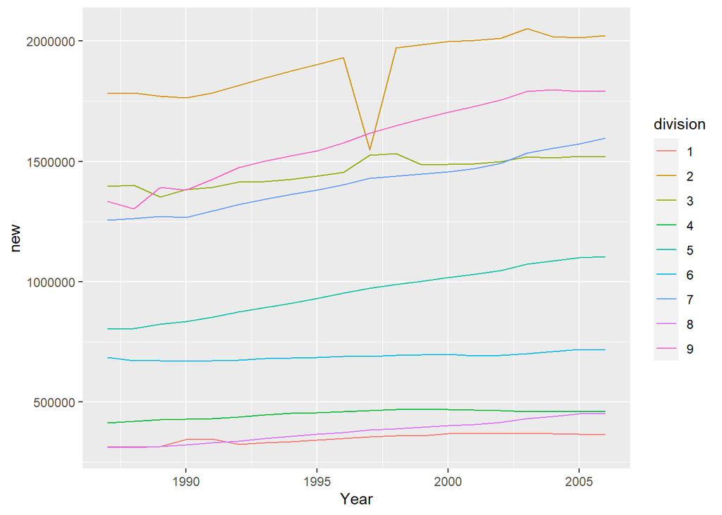

```r
#Plot the state data using thee self-defined function
plot.state(full_part$state)
```

4,Use the plot function on the county data frame

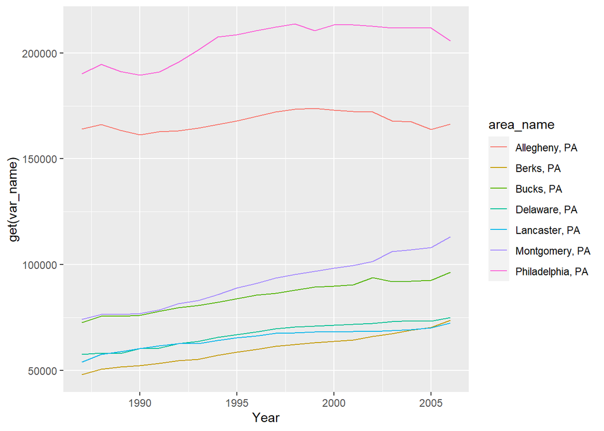

```r
#4.1 Specify the state to be "PA", top group and number looked at 7
plot.county(full_part$county,statename = "PA",order = "top",size = 7)
```

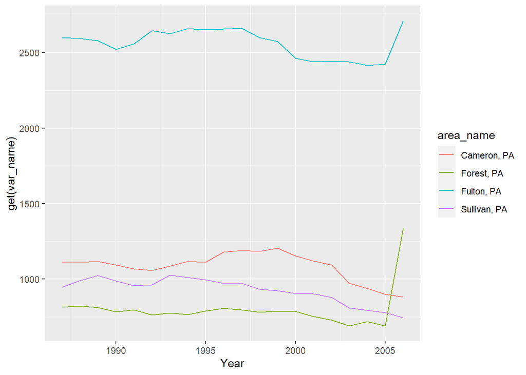

```r
#4.2 Specify the state to be "PA", bottom group and number looked at 4
plot.county(full_part$county,statename = "PA",order = "bottom",size = 4)
```

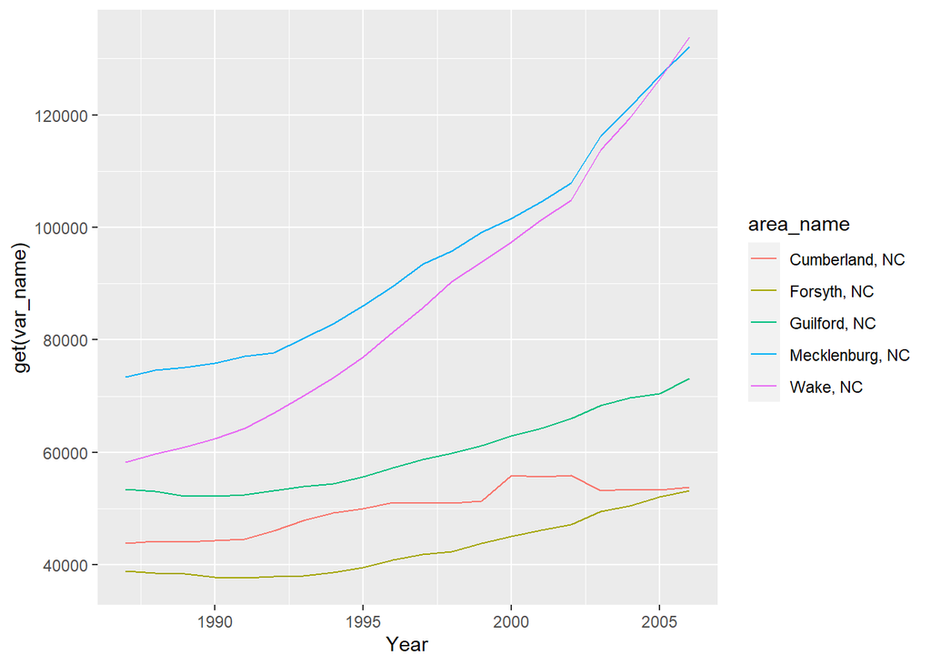

```r
#4.3 Use default value
plot.county(full_part$county)
```

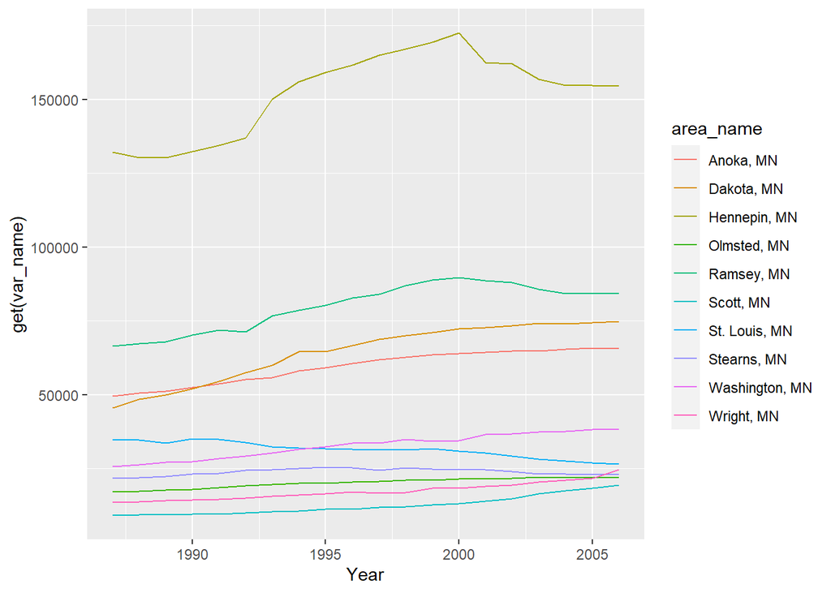

```r
#4.4 Specify the state to be "MN", top group and number looked at 10
plot.county(full_part$county,statename = "MN",order = "top",size = 10)
```

5.Read in other datasets and apply self-defined functions.

```r
#Read in 4 new datasets
newdata1 <- my_wrapper("https://www4.stat.ncsu.edu/~online/datasets/PST01a.csv")
newdata2 <- my_wrapper("https://www4.stat.ncsu.edu/~online/datasets/PST01b.csv")
newdata3 <- my_wrapper("https://www4.stat.ncsu.edu/~online/datasets/PST01c.csv")
newdata4 <- my_wrapper("https://www4.stat.ncsu.edu/~online/datasets/PST01d.csv")
#Combine data
full_newdata <- f_combine(newdata1,newdata2,newdata3,newdata4)
full_newdata
```

```
## $county
## # A tibble: 125,800 × 7
##    area_name   STCOU original_columns value  Year Measurement state
##    <chr>       <chr> <chr>            <dbl> <dbl> <chr>       <chr>
##  1 Autauga, AL 01001 PST015171D       25508  1971 PST0151     AL
##  2 Autauga, AL 01001 PST015172D       27166  1972 PST0151     AL
##  3 Autauga, AL 01001 PST015173D       28463  1973 PST0151     AL
##  4 Autauga, AL 01001 PST015174D       29266  1974 PST0151     AL
##  5 Autauga, AL 01001 PST015175D       29718  1975 PST0151     AL
##  6 Autauga, AL 01001 PST015176D       29896  1976 PST0151     AL
##  7 Autauga, AL 01001 PST015177D       30462  1977 PST0151     AL
##  8 Autauga, AL 01001 PST015178D       30882  1978 PST0151     AL
##  9 Autauga, AL 01001 PST015179D       32055  1979 PST0151     AL
## 10 Autauga, AL 01001 PST025181D       31985  1981 PST0251     AL
## # … with 125,790 more rows
##
## $state
## # A tibble: 2,120 × 7
##    area_name     STCOU original_columns     value  Year Measurement division
##    <chr>         <chr> <chr>                <dbl> <dbl> <chr>       <chr>
##  1 UNITED STATES 00000 PST015171D       206827028  1971 PST0151     ERROR
##  2 UNITED STATES 00000 PST015172D       209283904  1972 PST0151     ERROR
##  3 UNITED STATES 00000 PST015173D       211357490  1973 PST0151     ERROR
##  4 UNITED STATES 00000 PST015174D       213341552  1974 PST0151     ERROR
##  5 UNITED STATES 00000 PST015175D       215465246  1975 PST0151     ERROR
##  6 UNITED STATES 00000 PST015176D       217562728  1976 PST0151     ERROR
##  7 UNITED STATES 00000 PST015177D       219759860  1977 PST0151     ERROR
##  8 UNITED STATES 00000 PST015178D       222095080  1978 PST0151     ERROR
##  9 UNITED STATES 00000 PST015179D       224567234  1979 PST0151     ERROR
## 10 UNITED STATES 00000 PST025181D       229466391  1981 PST0251     ERROR
## # … with 2,110 more rows
```

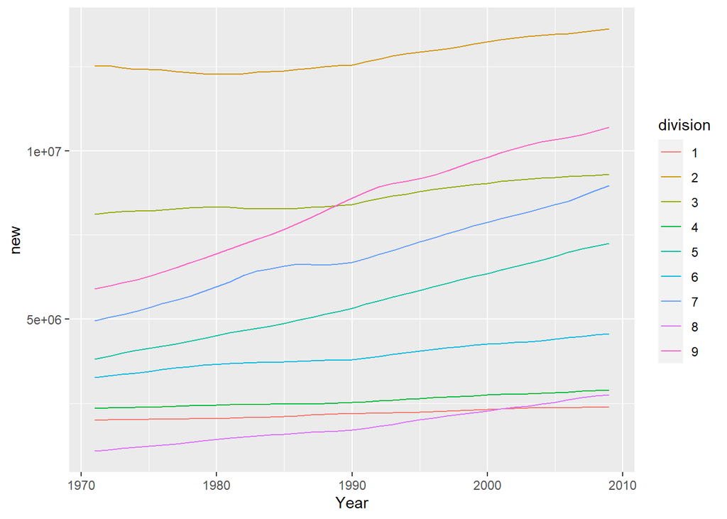

```r
#Use the plot function on the state data frame
plot.state(full_newdata$state)
```

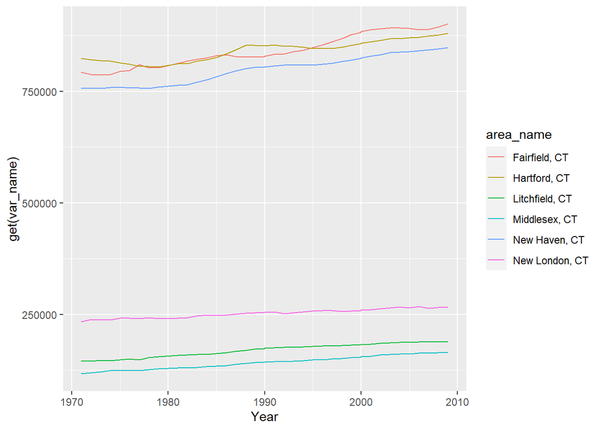

```r
#Use the plot function on the country data frame with specified input
#Specify the state to be "CT", top group and number looked at 6
plot.county(full_newdata$county,statename = "CT",order = "top",size = 6)
```

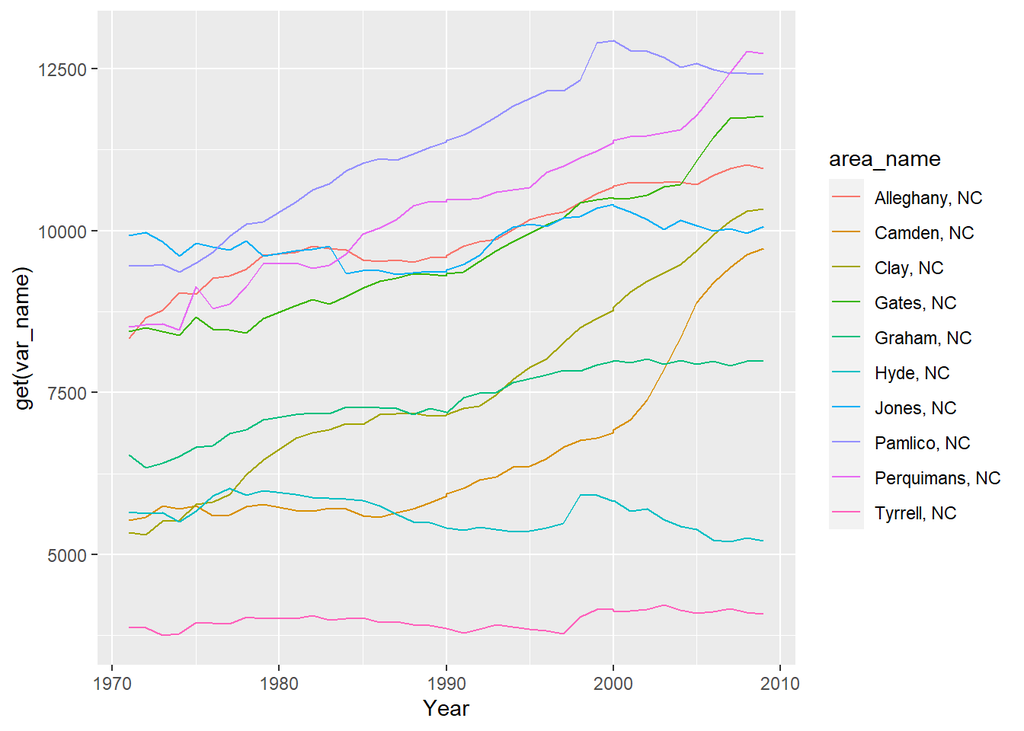

```r
#Specify the state to be "NC", bottom group and number looked at 10
plot.county(full_newdata$county,statename = "NC",order = "bottom",size = 10)
```

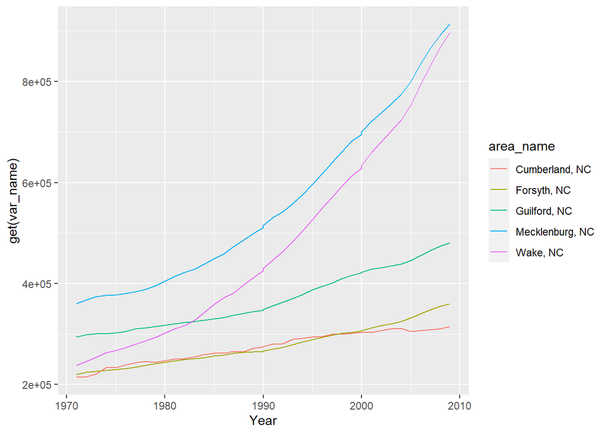

```r
#Defaults value used
plot.county(full_newdata$county)
```

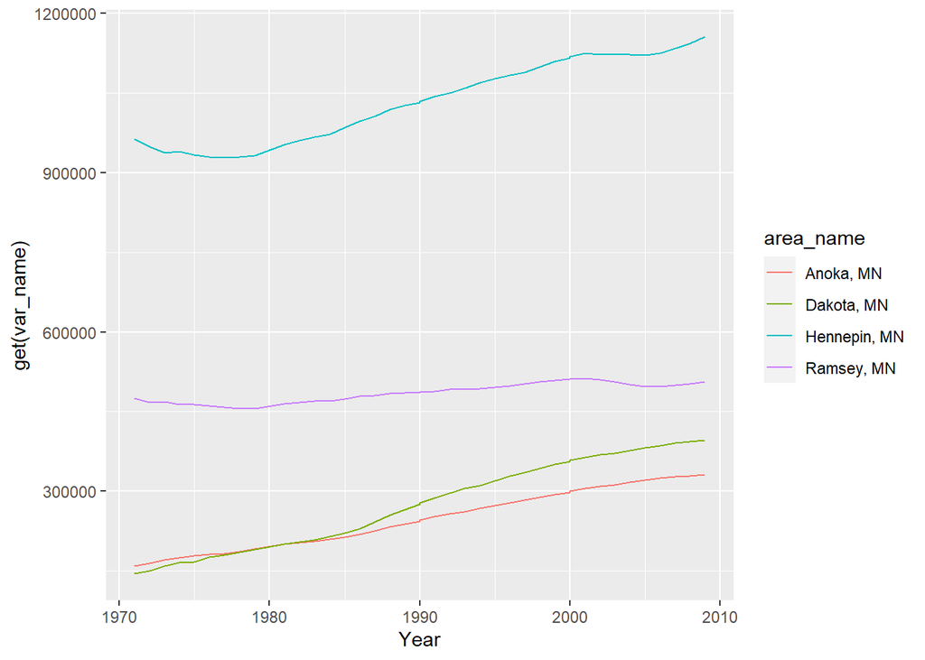

```r
#Specify the state to be "NMN", top group and number looked at 4
plot.county(full_newdata$county,statename = "MN",order = "top",size = 4)
```